# Human Activity Recognition From Weight Lifting Exercise Dataset Collected By Wearable Devices

July 26, 2015

# Synopsis

This is the report for the course project of Practical Machine Learning class provided by Johns Hopkins University and coursera.

In this project, we conduct human activity recognition using the data from accelerometers on the belt, forearm, arm, and dumbell of 6 participants. They were asked to perform barbell lifts correctly and incorrectly in 5 different ways. The data is available from the website: http://groupware.les.inf.puc-rio.br/har (see the section on the Weight Lifting Exercise(WLE) Dataset).

In this report we will describe the scenario of data retrieval, data clean and how we construct Machine Learning Models from the data extracted from the raw WLE dataset. We also conduct cross validation to evaluate the performance of the recognition models.

Our local machine is a MacBookPro 13-inch laptop with a 2.7GHz Intel Core i7 processor and 8G DDR3 Memory. The R version we use is 3.2.1(World-Famous Astronaut) and most packages are updated to date.

# Raw Data Retrival

We first download the raw data from the cloud to the local machine and load the raw data to the memory.

```r
# Download the raw training/testing data
raw.training.url <- "https://d396qusza40orc.cloudfront.net/predmachlearn/pml-training.csv"
raw.training.file <- "pml-training.csv"
if (!file.exists(raw.training.file))
  download.file(raw.training.url, raw.training.file,"curl")

raw.testing.url <- "https://d396qusza40orc.cloudfront.net/predmachlearn/pml-testing.csv"
raw.testing.file <- "pml-testing.csv"
if (!file.exists(raw.testing.file))
  download.file(raw.testing.url, raw.testing.file,"curl")

# Import raw traning/testing data into R enviroment
raw.training <- read.csv(raw.training.file, na.strings=c("NA",""), header=TRUE)
raw.testing <- read.csv(raw.testing.file, na.strings=c("NA",""), header=TRUE)
```

# Feature Selection and Data Clean

We first take a quick look on the raw traning data:

```r
str(raw.training)
```

```r
na.stat <- sapply(raw.training, function(x) length(which(is.na(x))))
table(na.stat)
```

```
## na.stat
##     0 19216
##    60   100
```

```r
tmp.df <- raw.training[ , na.stat ==0 ]
```

Apparently, the first seven variables `X`, `user_name`,`raw_timestamp_part_1`, `raw_timestamp_part_2`, `cvtd_timestamp`, `new_window`, `num_window` are not related to this research, so we choose to further remove these variables from the data frame `tmp.df`.

```r
df <- tmp.df[ , -c(1:7) ]
str(df)
```

```
## 'data.frame':    19622 obs. of  53 variables:
##  $ roll_belt           : num  1.41 1.41 1.42 1.48 1.48 1.45 1.42 1.42 1.43 1.45 ...
##  $ pitch_belt          : num  8.07 8.07 8.07 8.05 8.07 8.06 8.09 8.13 8.16 8.17 ...
##  $ yaw_belt            : num  -94.4 -94.4 -94.4 -94.4 -94.4 -94.4 -94.4 -94.4 -94.4 -94.4 ...
##  $ total_accel_belt    : int  3 3 3 3 3 3 3 3 3 3 ...
##  $ gyros_belt_x        : num  0 0.02 0 0.02 0.02 0.02 0.02 0.02 0.02 0.03 ...
##  $ gyros_belt_y        : num  0 0 0 0 0.02 0 0 0 0 0 ...
##  $ gyros_belt_z        : num  -0.02 -0.02 -0.02 -0.03 -0.02 -0.02 -0.02 -0.02 -0.02 0 ...
##  $ accel_belt_x        : int  -21 -22 -20 -22 -21 -21 -22 -22 -20 -21 ...
##  $ accel_belt_y        : int  4 4 5 3 2 4 3 4 2 4 ...
##  $ accel_belt_z        : int  22 22 23 21 24 21 21 21 24 22 ...
##  $ magnet_belt_x       : int  -3 -7 -2 -6 -6 0 -4 -2 1 -3 ...
##  $ magnet_belt_y       : int  599 608 600 604 600 603 599 603 602 609 ...
##  $ magnet_belt_z       : int  -313 -311 -305 -310 -302 -312 -311 -313 -312 -308 ...
##  $ roll_arm            : num  -128 -128 -128 -128 -128 -128 -128 -128 -128 -128 ...
```

[output cut: 39 more lines]

Now `df` is the data frame with the selected features that would be used in the following steps.

# Data Slicing

We follow the policy of partition of training:testing = 7:3 as usual.

```r
# load packages and data
library(caret)
# create training set indexes with 75% of data
inTrain <- createDataPartition(y=df$classe,p=0.7, list=FALSE)
# subset spam data to training
training <- df[inTrain,]
# subset spam data (the rest) to test
testing <- df[-inTrain,]
# dimension of original and training dataset
rbind("raw dataset" = dim(raw.training), "cleaned dataset" = dim(df),"training set" = dim(training))
```

```
##                  [,1] [,2]
## raw dataset     19622  160
## cleaned dataset 19622   53
## training set    13737   53
```

# Machine Learning Model 1: Classification Tree

We first try the classification tree on the `training` dataset with `classe` as the outcome and all the rest 52 variables as predictors.

```r
library(rpart)
library(rattle)
# fit classification tree as a model
modFit.ct <- rpart(classe ~ ., data = training, method = "class")
```

We then apply the classification tree model on the 30% testing data set to evaluate the performance of the model.

```r
predict.ct <- predict(modFit.ct, testing, type = "class")
confusionMatrix(testing$classe, predict.ct)
```

```
## Confusion Matrix and Statistics
##
##           Reference
## Prediction    A    B    C    D    E
##          A 1488   56   44   57   29
##          B  180  662  152   62   83
##          C   28   54  847   51   46
##          D   54   68  145  609   88
##          E   17   79  159   57  770
##
## Overall Statistics
##
##                Accuracy : 0.7436
##                  95% CI : (0.7322, 0.7547)
##     No Information Rate : 0.3003
##     P-Value [Acc > NIR] : < 2.2e-16
##
##                   Kappa : 0.6752
##  Mcnemar's Test P-Value : < 2.2e-16
##
## Statistics by Class:
##
##                      Class: A Class: B Class: C Class: D Class: E
## Sensitivity            0.8421   0.7203   0.6288   0.7285   0.7579
## Specificity            0.9548   0.9039   0.9606   0.9297   0.9359
## Pos Pred Value         0.8889   0.5812   0.8255   0.6317   0.7116
## Neg Pred Value         0.9337   0.9458   0.8971   0.9539   0.9488
## Prevalence             0.3003   0.1562   0.2289   0.1421   0.1726
## Detection Rate         0.2528   0.1125   0.1439   0.1035   0.1308
## Detection Prevalence   0.2845   0.1935   0.1743   0.1638   0.1839
## Balanced Accuracy      0.8985   0.8121   0.7947   0.8291   0.8469
```

From the confusion matrix output, we noticed that the accuracy of prediction is as low as 0.7436, which is not very satisfactory. So we decide to use the more complex and promising model of random forest.

# Machine Learning Model 2: Random Forest

Another free parameter is ntree, the number of trees. We tried 100, 200 and 500 and finally choose ntree=200, this is a good comprimise of accuracy and training speed.

When possible, we can turn on the `allowParallel` option to accelerate the speed of training.

We also found that using function call of `randomForest()` with the same syntax and parameters as `train()` would be much faster in the training process.

On our local machine, the training generally can converge in less than 3 minutes with the function parameters shown below. On the other hand, using all the training data set for the training purposes would take hours.

```r
library(randomForest)
set.seed(4543)
modFit.rf<-randomForest(classe ~ ., data=training,
                        trControl=trainControl(method="cv",number=3),method="rf",
                        ntree=200,prox=TRUE,allowParallel=TRUE,importance=TRUE)
modFit.rf
```

```
##
## Call:
##  randomForest(formula = classe ~ ., data = training, trControl = trainControl(method = "cv",      number = 3), method = "rf", ntree = 200, prox = TRUE, allowParallel = TRUE,      importance = TRUE)
##                Type of random forest: classification
##                      Number of trees: 200
## No. of variables tried at each split: 7
##
##         OOB estimate of  error rate: 0.55%
## Confusion matrix:
##      A    B    C    D    E  class.error
## A 3904    2    0    0    0 0.0005120328
## B   12 2637    8    0    1 0.0079006772
## C    0   15 2377    4    0 0.0079298831
## D    0    0   25 2224    3 0.0124333925
## E    0    0    2    3 2520 0.0019801980
```

We notice that the OOB estimate of error rate: 0.55%, which is very satisfactory.

To evalute the relative importance of the variables for the prediction, we turn on the importance option and show the top 15 most important variables in the Figure below.

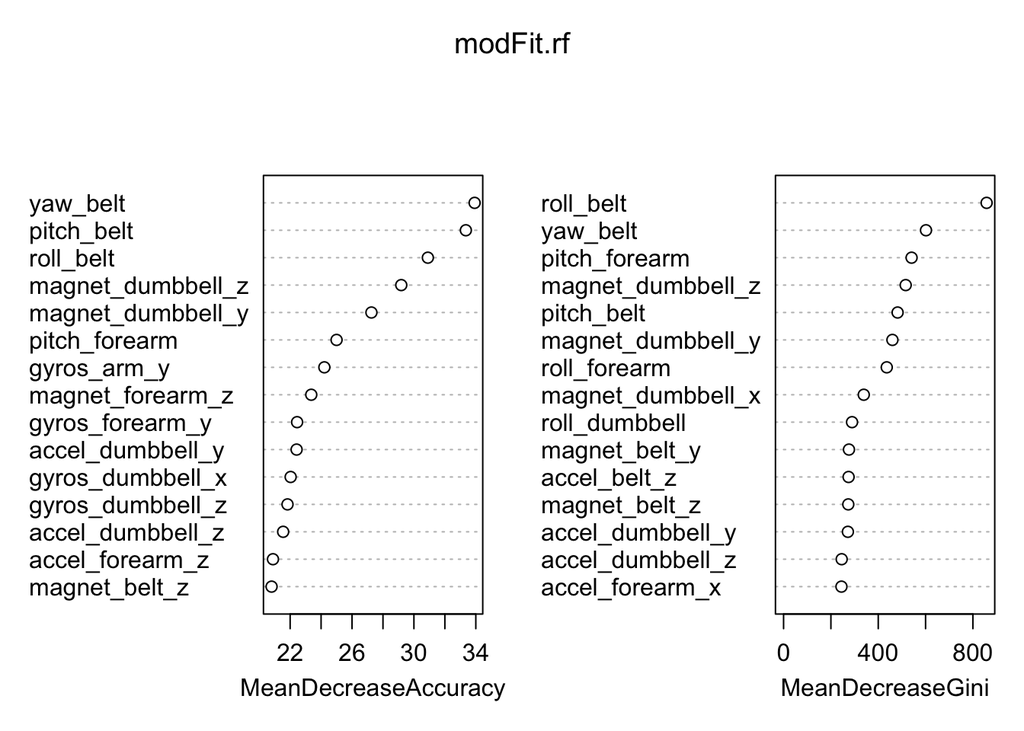

```r
varImpPlot(modFit.rf,n.var=15)
```

We can again apply the random forest model on the 30% testing dataset to evaluate the prediction performance of the model.

```r
predict.rf <- predict(modFit.rf, testing)
confusionMatrix(predict.rf, testing$classe)
```

```
## Confusion Matrix and Statistics
##
##           Reference
## Prediction    A    B    C    D    E
##          A 1673    5    0    0    0
##          B    1 1133    9    0    0
##          C    0    1 1017    8    1
##          D    0    0    0  955    3
##          E    0    0    0    1 1078
##
## Overall Statistics
##
##                Accuracy : 0.9951
##                  95% CI : (0.9929, 0.9967)
##     No Information Rate : 0.2845
##     P-Value [Acc > NIR] : < 2.2e-16
##
##                   Kappa : 0.9938
##  Mcnemar's Test P-Value : NA
##
## Statistics by Class:
##
##                      Class: A Class: B Class: C Class: D Class: E
## Sensitivity            0.9994   0.9947   0.9912   0.9907   0.9963
## Specificity            0.9988   0.9979   0.9979   0.9994   0.9998
## Pos Pred Value         0.9970   0.9913   0.9903   0.9969   0.9991
## Neg Pred Value         0.9998   0.9987   0.9981   0.9982   0.9992
## Prevalence             0.2845   0.1935   0.1743   0.1638   0.1839
## Detection Rate         0.2843   0.1925   0.1728   0.1623   0.1832
## Detection Prevalence   0.2851   0.1942   0.1745   0.1628   0.1833
## Balanced Accuracy      0.9991   0.9963   0.9946   0.9950   0.9980
```

From the `confusionMatrix()` output, we can found huge gain on prediction accuracy and other performance measurements over the classification tree model.

# Applying Random Forest Model on the Testing Dataset

Now we used the random forest model `modFit.rf` to predict results for the testing data downloaded before. The prediction answers are shown below.

```r
tmp.df <- raw.testing[ , na.stat ==0 ]
test.df <- tmp.df[ , -c(1:7) ]
predict(modFit.rf,test.df)
```

```
##  1  2  3  4  5  6  7  8  9 10 11 12 13 14 15 16 17 18 19 20
##  B  A  B  A  A  E  D  B  A  A  B  C  B  A  E  E  A  B  B  B
## Levels: A B C D E
```

Finally, we can use the function provided by the lecturer to generate the files for the submission part of the project.

```r
pml_write_files = function(x){
  n = length(x)
  for(i in 1:n){
    filename = paste0("problem_id_",i,".txt")
    write.table(x[i],file=filename,quote=FALSE,row.names=FALSE,col.names=FALSE)
  }
}
answers <- as.character(predict(modFit.rf,test.df))
pml_write_files(answers)
```